# Conditioning of Pacific hake operating model

Nis S Jacobsen (nissandjac@gmail.com)

November 13, 2019

## Data initialization

Load required packages

```r
library(TMB)
library(dplyr)
library(reshape2)
library(ggplot2)
library(r4ss)
```

Source the functions required to run the MSE (put into package later)

```r
source('load_files_OM.R')
```

Load the assessment data

```r
assessment <- read.csv('data/assessment_MLE.csv')
assessment <- assessment[assessment$year > 1965,]
mod <- SS_output(paste(getwd(),'/data/', sep =''), printstats=FALSE, verbose = FALSE, hidewarn = TRUE,
                 warn = FALSE
                  )
```

Initialize the model parameters. Make a version with no movement or seasons (simple)

```r
df <- load_data_seasons(nseason = 4, nspace = 2, bfuture = 0.5, movemaxinit = 0.5, movefiftyinit =8)
df.simple <- load_data_seasons(nseason = 1, nspace = 1, bfuture = 0.5) # Prepare data for operating model
```

Run the model using ’run.agebased.true.catch()

```r
sim.data <- run.agebased.true.catch(df)
sim.data.simple <- run.agebased.true.catch(df.simple)
```

Plot the spawning biomass of the operating model. The diffference in spawning biomass is due to spatial structure

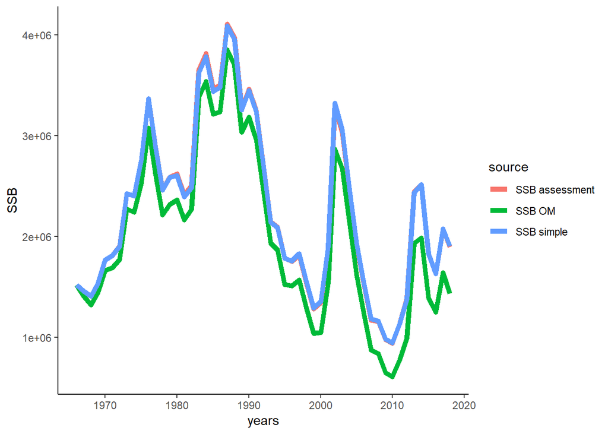

Plot the survey data and estimates

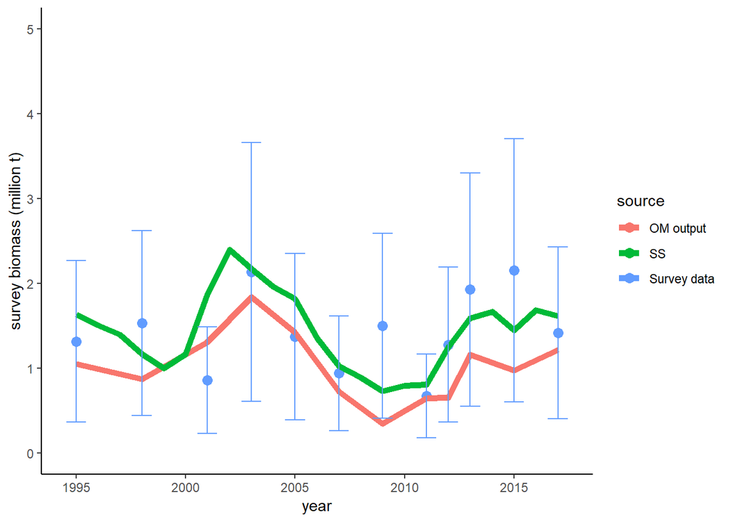

Calculate average ages using the calcMeanAge() function

```r
source('calcMeanAge.R')

age.comps <- sim.data$age_comps_OM[,1:df$nyear,,3]
age.comps <- apply(age.comps,c(1,2),sum)/2

am <- calcMeanAge(age.comps,df$nage)
```

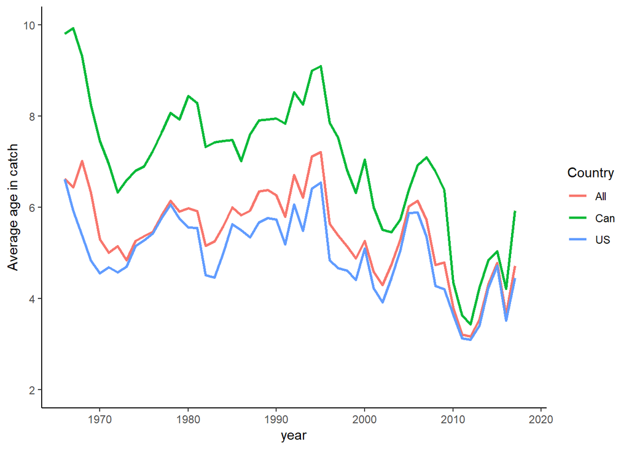

# png(‘Age_comps_catch.png’, width = 16, height = 12, res = 400,units = ‘cm’)

# p3

# dev.off()

## See thcoe catch per country

c.country <- read.csv(‘data/catch_per_country.csv’)

cps <- read.csv(‘data/catch_per_sector.csv’)

## Calculate

cps.s <- melt(cps, id.vars = c(‘year’,‘nfish’,‘nhauls’,‘Country’,‘Catch’), measure.vars = rep(paste(‘X’,1:15, sep =’’))) # Omit fleet from this df

cps.s <- cps.s %>% group_by(year,Country, variable) %>% summarise(agecomp =weighted.mean(value,Catch))

# Make ages numbers rather than factors

cps.s$age <- ages

cps.am <- cps.s %>% group_by(year,Country) %>% summarise(am = sum((agecomp/100)*age))

cps.am.all <- matrix(NA, df$nyear)

for(i in 1:df$nyear){ cps.am.all[i] <- sum(df$age[2:16]*df$age_catch[,i]) }

df.am.all <- data.frame(year = df$years, Country = ‘All’,am = cps.am.all)

p1 <- ggplot(cps.am, aes(x= year, y= am, color = Country, group = Country))+geom_line()+geom_point()+theme_classic()+ geom_line(data = df.am.catch, linetype = 2)+ scale_x_continuous(limit = c(1990,2017))+scale_y_continuous(limit = c(2.5,10),name = ‘average age in catch’)+ geom_line(data = df.am.all, col = ‘red’)+geom_point(data=df.am.all, col =‘red’)

# png(‘age_comps.png’, width = 16, height = 12, res = 400,units = ‘cm’)

# Is my weighted calculation correct?

cps.all$age <- ages

cps.all.s <- cps.all %>% group_by(year) %>% summarise(am = sum((agecomp/100)*age))

[output not shown]